# FA1

# Covariation

## Discrete versus discrete

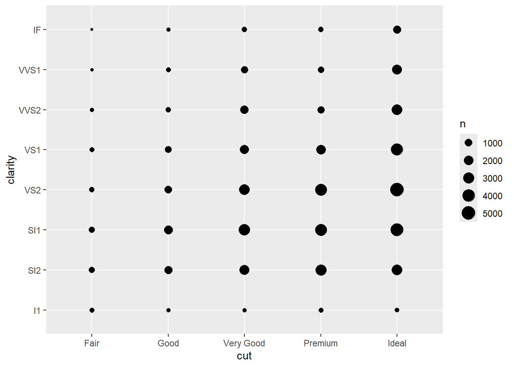

```r
ggplot(data = diamonds) +
geom_count(mapping = aes(x = cut, y = clarity))
```

The relationship between cut and clarity will depend on how the distribution of clarity varies across different levels of cut. So, the higher quality cuts are more likely have higher clarity.

# Continuous Versus Continuous

## Many to One

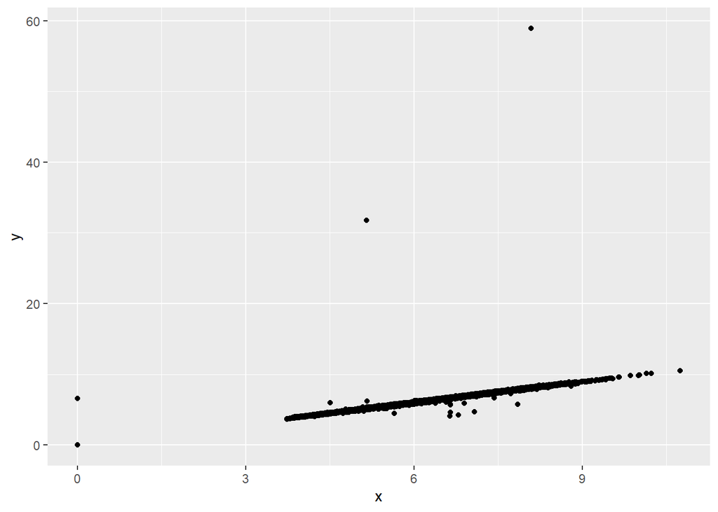

```r
ggplot(data = diamonds) +
geom_point(mapping = aes(x = x, y = y))
```

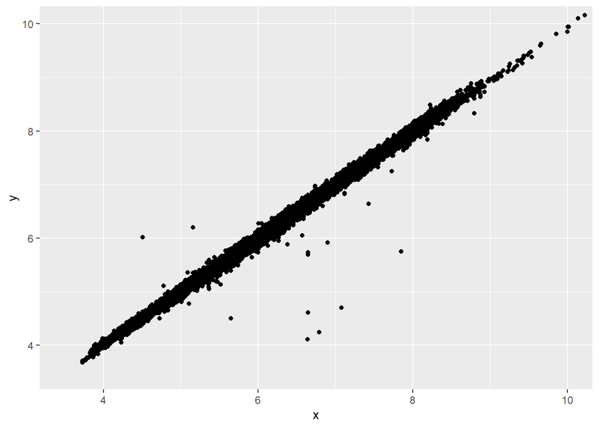

```r
ggplot(data = diamonds) +
geom_point(mapping = aes(x = x, y = y)) +
coord_cartesian(xlim = c(3.5, 10), ylim = c(3.5,10))
```

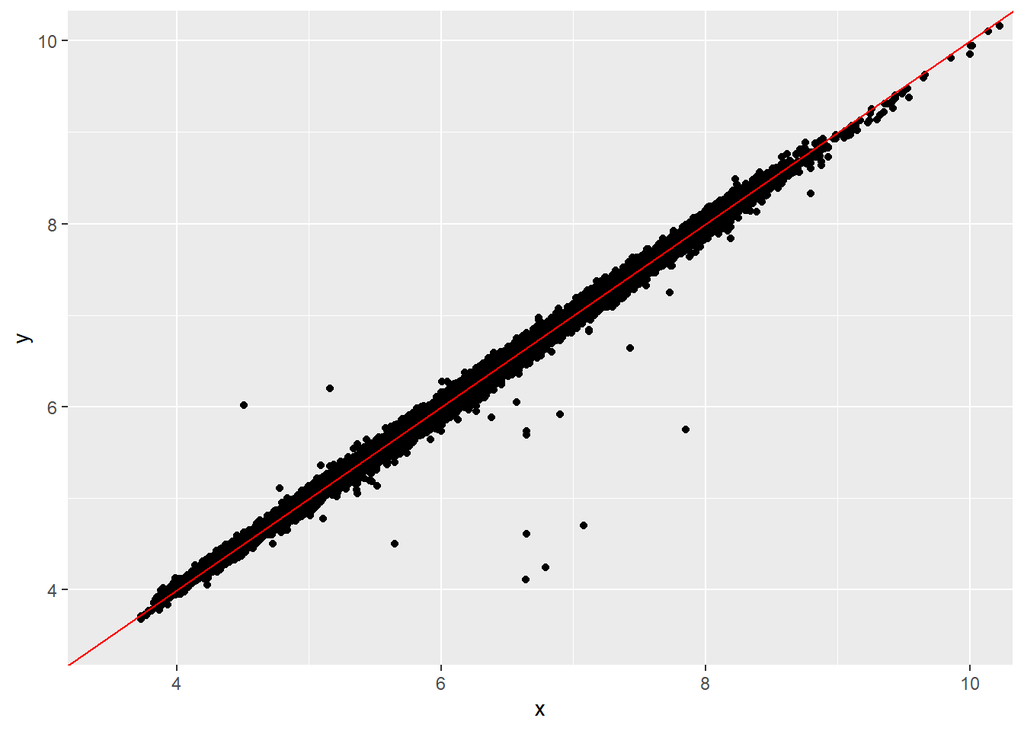

```r
ggplot(data = diamonds) +
geom_point(mapping = aes(x = x, y = y)) +
geom_abline(slope = 1, intercept = 0, color = "red") +
coord_cartesian(xlim = c(3.5, 10), ylim = c(3.5,10))
```

Since x and y values indicate the length and breadth of the diamonds, which are usually near in size, particularly for well-proportioned diamonds like round cuts, they are frequently identical for many diamonds. Since these are parameters for the plot’s visual components rather than data variables, the fixed values slope = 1, intercept = 0, and color = “red” should be given outside of aes().

## One to One

```r
avg_price_by_carat <- diamonds %>%
mutate(carat = round(carat, 1)) %>%
group_by(carat) %>%
summarise(avg_price = mean(price))
avg_price_by_carat
```

```
## # A tibble: 38 × 2
##    carat avg_price
##    <dbl>     <dbl>
##  1   0.2      506.
##  2   0.3      709.
##  3   0.4      936.
##  4   0.5     1590.
##  5   0.6     1861.
##  6   0.7     2619.
##  7   0.8     2998.
##  8   0.9     3942.
##  9   1       5437.
## 10   1.1     6011.
## # ℹ 28 more rows
```

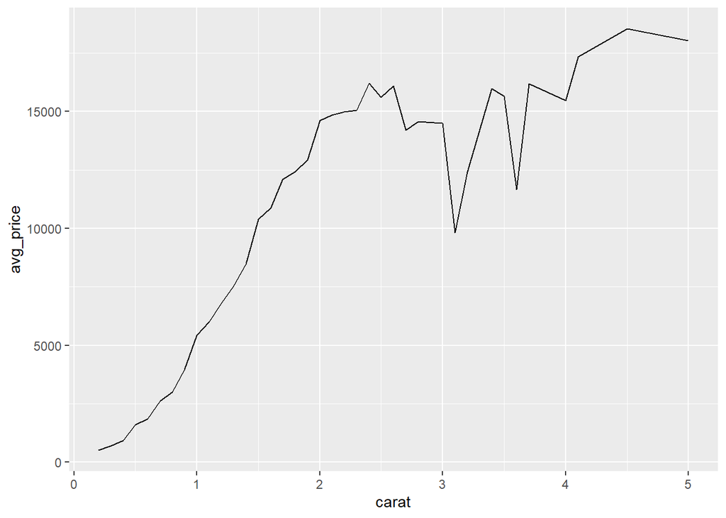

```r
ggplot(data = avg_price_by_carat) +
geom_line(mapping = aes(x = carat, y = avg_price))
```

The relationship of the average price and carat does make sense, since as the carat of the diamonds larger the price would be more pricey. However, other variables can change the value of the diamonds, so the relationship is not perfectly linear.